# Module 126

#### Contrast SVE:

Signed variance explained (SVE) provides an indication of how similar a set of fold changes are to a gene module’s weight vector. An SVE value of 0.3, for example, indicates that 30% of the variance explained by the entire module set is accounted for by the module in question. Shown here are the SVE values for this module across a compendium of fold changes (contrasts). Extreme SVE values (e.g., > 0.05) indicate that those contrasts specifically induce (orange dots) or specifically repress (blue dots) this module. Examining the experimental conditions being compared in such contrasts (see tables below the figure) may provide insight into the gene module’s function.

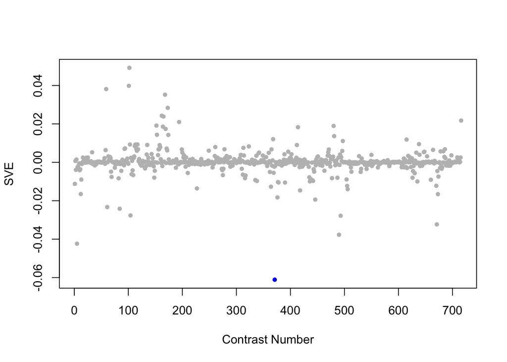

Positive SVE Contrasts:

|  | Contrast.Num | SVE | GEO.GSE | Cond.1 | Cond.2 | Mutation |
| --- | --- | --- | --- | --- | --- | --- |
| GSE5793.s2t2.vs.s2t1 | 102 | 0.05 | GSE5793 | Celegans_OP50_8hours_RepA | Celegans_OP50_4hours_RepA |  |
| GSE5793.s1t2.vs.s1t1 | 101 | 0.04 | GSE5793 | Celegans_gacA_8hours_RepA | Celegans_gacA_4hours_RepA |  |
| GSE9301.s2t1.vs.s1t1 | 59 | 0.04 | GSE9301 | 3-day-old TJ1090 worms with skn-1 RNAi & oxidative stress (SO1) | 3-day-old TJ1090 worms with oxidative stress (O1) | skn-1 |
| GSE47778.s1t3.vs.s3t3 | 168 | 0.04 | GSE47778 | N2; UV; replicate 1 | daf-16; UV; replicate 1 | daf-16 |
| GSE47778.s1t3.vs.s4t3 | 173 | 0.03 | GSE47778 | N2; UV; replicate 1 | daf-2;daf-16; UV; replicate 1 | daf-2;daf-16 |

Negative SVE Contrasts:

|  | Contrast.Num | SVE | GEO.GSE | Cond.1 | Cond.2 | Mutation |
| --- | --- | --- | --- | --- | --- | --- |
| GSE35360C.s1t1.vs.s0t1 | 371 | -0.06 | GSE35360 | HFHQ 3d_0.2_rep1 | HFHQ 3d control_rep1 |  |
| GSE9897B.s2t1.vs.s0t1 | 5 | -0.04 | GSE9897 | Complex I RNAi Mutant 2 | Wildtype (control for RNAi) | Y45G12B.1 |
| GSE23528B.s1t4.vs.s1t1 | 490 | -0.04 | GSE23528 | Adult at T38 in CC, time-series experiment 3 | Adult at T26 in CC, time-series experiment 3 |  |
| GSE15016.s1t1.vs.s0t1 | 671 | -0.03 | GSE15016 | young adult_24hr AgNPs exposure_rep1 | young adult_not exposured_rep1 |  |
| GSE23528C.s1t2.vs.s1t1 | 493 | -0.03 | GSE23528 | Adult at T30 in DD, time-series experiment 2 | Adult at T26 in DD, time-series experiment 2 |  |

$~$

#### Contrast SVE, Up-Regulated Genes Only:

Calculating SVE for up-regulated and down-regulated genes separately may be more informative in many cases than projecting the up- and down- gene sets together. This is due to the fact that the weight distribution of many modules is highly skewed, indicating that only one of the hemi-modules may be biologically meaningful (i.e., a set of genes are strongly correlated by only a few genes (or none) are strongly anti-correlated to that set.)

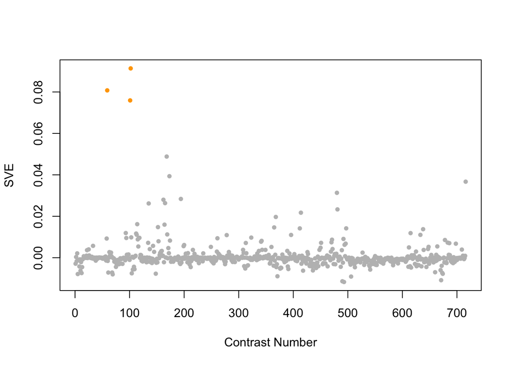

Positive SVE Contrasts:

|  | Contrast.Num | SVE | GEO.GSE | Cond.1 | Cond.2 | Mutation |
| --- | --- | --- | --- | --- | --- | --- |
| GSE5793.s2t2.vs.s2t1 | 102 | 0.09 | GSE5793 | Celegans_OP50_8hours_RepA | Celegans_OP50_4hours_RepA |  |
| GSE9301.s2t1.vs.s1t1 | 59 | 0.08 | GSE9301 | 3-day-old TJ1090 worms with skn-1 RNAi & oxidative stress (SO1) | 3-day-old TJ1090 worms with oxidative stress (O1) | skn-1 |
| GSE5793.s1t2.vs.s1t1 | 101 | 0.08 | GSE5793 | Celegans_gacA_8hours_RepA | Celegans_gacA_4hours_RepA |  |
| GSE47778.s1t3.vs.s3t3 | 168 | 0.05 | GSE47778 | N2; UV; replicate 1 | daf-16; UV; replicate 1 | daf-16 |
| GSE47778.s1t3.vs.s4t3 | 173 | 0.04 | GSE47778 | N2; UV; replicate 1 | daf-2;daf-16; UV; replicate 1 | daf-2;daf-16 |

Negative SVE Contrasts:

|  | Contrast.Num | SVE | GEO.GSE | Cond.1 | Cond.2 | Mutation |
| --- | --- | --- | --- | --- | --- | --- |
| GSE23528C.s1t2.vs.s1t1 | 493 | -0.01 | GSE23528 | Adult at T30 in DD, time-series experiment 2 | Adult at T26 in DD, time-series experiment 2 |  |
| GSE23528B.s1t4.vs.s1t1 | 490 | -0.01 | GSE23528 | Adult at T38 in CC, time-series experiment 3 | Adult at T26 in CC, time-series experiment 3 |  |
| GSE15016.s1t1.vs.s0t1 | 671 | -0.01 | GSE15016 | young adult_24hr AgNPs exposure_rep1 | young adult_not exposured_rep1 |  |
| GSE2210.s1t1.vs.s0t1 | 506 | -0.01 | GSE2210 | tom-1(nu468) Sample 1 | Wild type Sample 1 | tom-1 |
| GSE35360C.s1t1.vs.s0t1 | 371 | -0.01 | GSE35360 | HFHQ 3d_0.2_rep1 | HFHQ 3d control_rep1 |  |

$~$

#### Contrast SVE, Down-Regulated Genes Only:

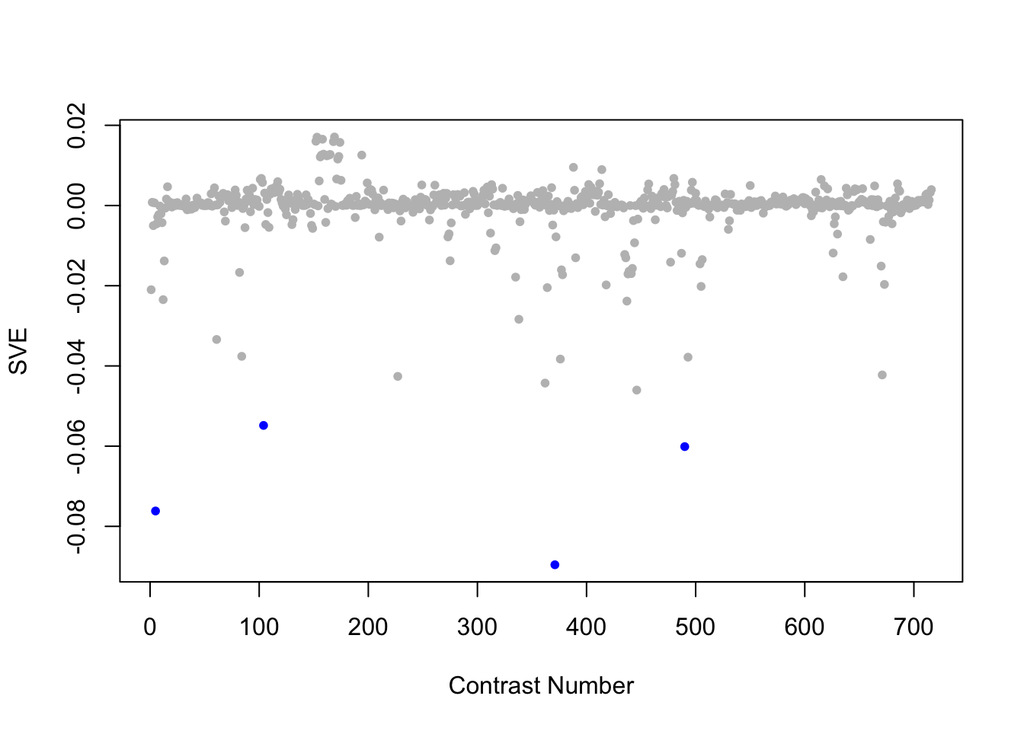

Positive SVE Contrasts:

|  | Contrast.Num | SVE | GEO.GSE | Cond.1 | Cond.2 | Mutation |
| --- | --- | --- | --- | --- | --- | --- |
| GSE47778.s5t3.vs.s3t3 | 169 | 0.02 | GSE47778 | xpa-1 10mJ/cm2; replicate 1 | daf-16; UV; replicate 1 | xpa-1 vs. daf-16 |
| GSE47778.s5t1.vs.s3t1 | 153 | 0.02 | GSE47778 | xpa-1 0mJ/cm2; replicate 1 | daf-16; replicate 1 | xpa-1 vs. daf-16 |
| GSE47778.s5t1.vs.s4t1 | 158 | 0.02 | GSE47778 | xpa-1 0mJ/cm2; replicate 1 | daf-2;daf-16; replicate 1 | xpa-1 vs. daf-2;daf-16 |
| GSE47778.s1t1.vs.s3t1 | 152 | 0.02 | GSE47778 | N2; replicate 1 | daf-16; replicate 1 | daf-16 |
| GSE47778.s1t3.vs.s3t3 | 168 | 0.02 | GSE47778 | N2; UV; replicate 1 | daf-16; UV; replicate 1 | daf-16 |

Negative SVE Contrasts:

|  | Contrast.Num | SVE | GEO.GSE | Cond.1 | Cond.2 | Mutation |
| --- | --- | --- | --- | --- | --- | --- |
| GSE35360C.s1t1.vs.s0t1 | 371 | -0.09 | GSE35360 | HFHQ 3d_0.2_rep1 | HFHQ 3d control_rep1 |  |
| GSE9897B.s2t1.vs.s0t1 | 5 | -0.08 | GSE9897 | Complex I RNAi Mutant 2 | Wildtype (control for RNAi) | Y45G12B.1 |
| GSE23528B.s1t4.vs.s1t1 | 490 | -0.06 | GSE23528 | Adult at T38 in CC, time-series experiment 3 | Adult at T26 in CC, time-series experiment 3 |  |
| GSE57664.s1t1.vs.s0t1 | 104 | -0.05 | GSE57664 | TYR treated rep1 | control rep1 |  |
| GSE27401.s2t1.vs.s3t1 | 446 | -0.05 | GSE27401 | Heat Killed C. albicans #1 | C. albicans alive #1 |  |

$~$

$~$

#### GO Term Enrichment:

This analysis tests each hemi-module for enrichment of specific GO terms. Only gene-level annotations (e.g., as would be found on the gene’s page in Wormbase) are tested - the hierarchical structure of the GO ontology is not taken into account.

*Note: At least the top two most enriched terms from each GO domain (BP/MF/CC) are shown, even when not statistically significant.*

##### Enriched GO terms: Hemi-module A

| ID | GO.Term | GO Domain | Raw p-value | Adj p-value |
| --- | --- | --- | --- | --- |
| [GO_0007275](http://amigo.geneontology.org/amigo/term/GO:0007275) | multicellular organism development | BP | 3.50e-08 | 1.27e-04 |
| [GO_0009792](http://amigo.geneontology.org/amigo/term/GO:0009792) | embryo development ending in birth or egg hatching | BP | 5.50e-07 | 1.00e-03 |
| [GO_0007049](http://amigo.geneontology.org/amigo/term/GO:0007049) | cell cycle | BP | 3.50e-06 | 4.25e-03 |
| [GO_0017148](http://amigo.geneontology.org/amigo/term/GO:0017148) | negative regulation of translation | BP | 3.42e-05 | 3.11e-02 |
| [GO_0006417](http://amigo.geneontology.org/amigo/term/GO:0006417) | regulation of translation | BP | 5.10e-05 | 3.71e-02 |
| [GO_0051301](http://amigo.geneontology.org/amigo/term/GO:0051301) | cell division | BP | 8.88e-05 | 5.39e-02 |
| [GO_0005515](http://amigo.geneontology.org/amigo/term/GO:0005515) | protein binding | MF | 1.52e-10 | 3.11e-07 |
| [GO_0000166](http://amigo.geneontology.org/amigo/term/GO:0000166) | nucleotide binding | MF | 6.15e-07 | 5.22e-04 |
| [GO_0005524](http://amigo.geneontology.org/amigo/term/GO:0005524) | ATP binding | MF | 7.67e-07 | 5.22e-04 |
| [GO_0016021](http://amigo.geneontology.org/amigo/term/GO:0016021) | integral component of membrane | CC | 2.82e-09 | 2.61e-06 |
| [GO_0005737](http://amigo.geneontology.org/amigo/term/GO:0005737) | cytoplasm | CC | 5.51e-08 | 2.56e-05 |
| [GO_0031965](http://amigo.geneontology.org/amigo/term/GO:0031965) | nuclear membrane | CC | 3.72e-06 | 1.15e-03 |
| [GO_0016020](http://amigo.geneontology.org/amigo/term/GO:0016020) | membrane | CC | 6.04e-06 | 1.40e-03 |
| [GO_0043186](http://amigo.geneontology.org/amigo/term/GO:0043186) | P granule | CC | 1.30e-04 | 2.40e-02 |
| [GO_0017119](http://amigo.geneontology.org/amigo/term/GO:0017119) | Golgi transport complex | CC | 1.58e-04 | 2.43e-02 |
| [GO_0005634](http://amigo.geneontology.org/amigo/term/GO:0005634) | nucleus | CC | 1.83e-04 | 2.43e-02 |
| [GO_0031379](http://amigo.geneontology.org/amigo/term/GO:0031379) | RNA-directed RNA polymerase complex | CC | 2.83e-04 | 3.29e-02 |
| [GO_0005768](http://amigo.geneontology.org/amigo/term/GO:0005768) | endosome | CC | 7.73e-04 | 7.97e-02 |

##### Enriched GO terms: Hemi-module B

| ID | GO.Term | GO Domain | Raw p-value | Adj p-value |
| --- | --- | --- | --- | --- |
| [GO_0045128](http://amigo.geneontology.org/amigo/term/GO:0045128) | negative regulation of reciprocal meiotic recombination | BP | 8.31e-04 | 9.45e-01 |
| [GO_0048213](http://amigo.geneontology.org/amigo/term/GO:0048213) | Golgi vesicle prefusion complex stabilization | BP | 8.31e-04 | 9.45e-01 |
| [GO_0019901](http://amigo.geneontology.org/amigo/term/GO:0019901) | protein kinase binding | MF | 1.67e-03 | 1.00e+00 |
| [GO_0000146](http://amigo.geneontology.org/amigo/term/GO:0000146) | microfilament motor activity | MF | 2.49e-03 | 1.00e+00 |
| [GO_0016460](http://amigo.geneontology.org/amigo/term/GO:0016460) | myosin II complex | CC | 8.31e-04 | 3.52e-01 |
| [GO_0070938](http://amigo.geneontology.org/amigo/term/GO:0070938) | contractile ring | CC | 8.31e-04 | 3.52e-01 |

$~$

$~$

#### Tissue Enrichment:

This analysis tests each hemi-module for enrichment of genes associated with anatomy terms. Negative enrichment scores indicate fewer hemi-module genes than expected by random chance were associated with the anatomy term in question.

##### Enriched tissues: Hemi-module A

| ID | Anatomy.Term | Definition | Raw p-value | Adj p-value |
| --- | --- | --- | --- | --- |
| [WBbt_0003681](https://wormbase.org/species/all/anatomy_term/WBbt:0003681) | pharynx | the feeding organ, a neuro-muscular pump in the head of the animal, used to ingest food, bacteria suspended in liquid, filter them out, grind them up and transport posteriorly into the instestine. | 1.65e-06 | 4.01e-03 |

##### Enriched tissues: Hemi-module B

No significant annotations.

$~$

$~$

#### HOMER promoter motif enrichment:

This analysis tests each hemi-module for enrichment of 108 known *C. elegans* transcription factor binding site motifs (see [108 CE motifs](https://katiepod.github.io//all.worm.motifs.html)) using the HOMER (Hypergeometric Optimization of Motif EnRichment) software (see [PMID:20513432](https://pubmed.ncbi.nlm.nih.gov/20513432)). HOMER was run using default parameters on sequences 1 kb upstream of the transcription start site.

##### Motif enrichment: Hemi-module A

Total target sequences = 232  
Total background sequences = 35543  
* - possible false positive

Rank

Motif

P-value

log P-pvalue

% of Targets

% of Background

STD(Bg STD)

Best Match/Details

Motif File

1

[figure not shown]

1e-13

-2.998e+01

34.91%

15.12%

299.6bp (405.5bp)

ceh-38/MA1699.1/Jaspar(0.790)  
[More Information](https://katiepod.github.io/HomerResults/m126_a_hemi_genes.txt.out.1kb/homerResults/motif1.info.html) | [Similar Motifs Found](https://katiepod.github.io/HomerResults/m126_a_hemi_genes.txt.out.1kb/homerResults/motif1.similar.html)

[motif file (matrix)](https://katiepod.github.io/HomerResults/m126_a_hemi_genes.txt.out.1kb/homerResults/motif1.motif)

2

[figure not shown]

1e-12

-2.819e+01

4.31%

0.11%

259.5bp (305.9bp)

POL009.1_DCE_S_II/Jaspar(0.614)  
[More Information](https://katiepod.github.io/HomerResults/m126_a_hemi_genes.txt.out.1kb/homerResults/motif2.info.html) | [Similar Motifs Found](https://katiepod.github.io/HomerResults/m126_a_hemi_genes.txt.out.1kb/homerResults/motif2.similar.html)

[motif file (matrix)](https://katiepod.github.io/HomerResults/m126_a_hemi_genes.txt.out.1kb/homerResults/motif2.motif)

3 *

[figure not shown]

1e-10

-2.497e+01

2.59%

0.01%

221.5bp (198.1bp)

MF0004.1_Nuclear_Receptor_class/Jaspar(0.536)  
[More Information](https://katiepod.github.io/HomerResults/m126_a_hemi_genes.txt.out.1kb/homerResults/motif3.info.html) | [Similar Motifs Found](https://katiepod.github.io/HomerResults/m126_a_hemi_genes.txt.out.1kb/homerResults/motif3.similar.html)

[motif file (matrix)](https://katiepod.github.io/HomerResults/m126_a_hemi_genes.txt.out.1kb/homerResults/motif3.motif)

4 *

[figure not shown]

1e-10

-2.350e+01

4.31%

0.19%

323.8bp (300.4bp)

MF0002.1_bZIP_CREB/G-box-like_subclass/Jaspar(0.595)  
[More Information](https://katiepod.github.io/HomerResults/m126_a_hemi_genes.txt.out.1kb/homerResults/motif4.info.html) | [Similar Motifs Found](https://katiepod.github.io/HomerResults/m126_a_hemi_genes.txt.out.1kb/homerResults/motif4.similar.html)

[motif file (matrix)](https://katiepod.github.io/HomerResults/m126_a_hemi_genes.txt.out.1kb/homerResults/motif4.motif)

5 *

[figure not shown]

1e-9

-2.285e+01

9.48%

1.66%

227.9bp (375.5bp)

MF0002.1_bZIP_CREB/G-box-like_subclass/Jaspar(0.627)  
[More Information](https://katiepod.github.io/HomerResults/m126_a_hemi_genes.txt.out.1kb/homerResults/motif5.info.html) | [Similar Motifs Found](https://katiepod.github.io/HomerResults/m126_a_hemi_genes.txt.out.1kb/homerResults/motif5.similar.html)

[motif file (matrix)](https://katiepod.github.io/HomerResults/m126_a_hemi_genes.txt.out.1kb/homerResults/motif5.motif)

6 *

[figure not shown]

1e-9

-2.263e+01

12.07%

2.79%

267.3bp (392.5bp)

ceh-38/MA1699.1/Jaspar(0.627)  
[More Information](https://katiepod.github.io/HomerResults/m126_a_hemi_genes.txt.out.1kb/homerResults/motif6.info.html) | [Similar Motifs Found](https://katiepod.github.io/HomerResults/m126_a_hemi_genes.txt.out.1kb/homerResults/motif6.similar.html)

[motif file (matrix)](https://katiepod.github.io/HomerResults/m126_a_hemi_genes.txt.out.1kb/homerResults/motif6.motif)

7 *

[figure not shown]

1e-9

-2.238e+01

25.43%

10.62%

258.6bp (356.1bp)

daf-16/MA1446.1/Jaspar(0.732)  
[More Information](https://katiepod.github.io/HomerResults/m126_a_hemi_genes.txt.out.1kb/homerResults/motif7.info.html) | [Similar Motifs Found](https://katiepod.github.io/HomerResults/m126_a_hemi_genes.txt.out.1kb/homerResults/motif7.similar.html)

[motif file (matrix)](https://katiepod.github.io/HomerResults/m126_a_hemi_genes.txt.out.1kb/homerResults/motif7.motif)

8 *

[figure not shown]

1e-9

-2.192e+01

36.21%

18.68%

288.3bp (379.0bp)

MF0010.1_Homeobox_class/Jaspar(0.596)  
[More Information](https://katiepod.github.io/HomerResults/m126_a_hemi_genes.txt.out.1kb/homerResults/motif8.info.html) | [Similar Motifs Found](https://katiepod.github.io/HomerResults/m126_a_hemi_genes.txt.out.1kb/homerResults/motif8.similar.html)

[motif file (matrix)](https://katiepod.github.io/HomerResults/m126_a_hemi_genes.txt.out.1kb/homerResults/motif8.motif)

9 *

[figure not shown]

1e-9

-2.159e+01

4.74%

0.31%

284.4bp (403.4bp)

POL008.1_DCE_S_I/Jaspar(0.481)  
[More Information](https://katiepod.github.io/HomerResults/m126_a_hemi_genes.txt.out.1kb/homerResults/motif9.info.html) | [Similar Motifs Found](https://katiepod.github.io/HomerResults/m126_a_hemi_genes.txt.out.1kb/homerResults/motif9.similar.html)

[motif file (matrix)](https://katiepod.github.io/HomerResults/m126_a_hemi_genes.txt.out.1kb/homerResults/motif9.motif)

10 *

[figure not shown]

1e-9

-2.158e+01

29.74%

13.90%

276.0bp (384.3bp)

daf-12/MA0538.1/Jaspar(0.679)  
[More Information](https://katiepod.github.io/HomerResults/m126_a_hemi_genes.txt.out.1kb/homerResults/motif10.info.html) | [Similar Motifs Found](https://katiepod.github.io/HomerResults/m126_a_hemi_genes.txt.out.1kb/homerResults/motif10.similar.html)

[motif file (matrix)](https://katiepod.github.io/HomerResults/m126_a_hemi_genes.txt.out.1kb/homerResults/motif10.motif)

11 *

[figure not shown]

1e-8

-2.053e+01

2.59%

0.03%

238.7bp (334.3bp)

POL011.1_XCPE1/Jaspar(0.605)  
[More Information](https://katiepod.github.io/HomerResults/m126_a_hemi_genes.txt.out.1kb/homerResults/motif11.info.html) | [Similar Motifs Found](https://katiepod.github.io/HomerResults/m126_a_hemi_genes.txt.out.1kb/homerResults/motif11.similar.html)

[motif file (matrix)](https://katiepod.github.io/HomerResults/m126_a_hemi_genes.txt.out.1kb/homerResults/motif11.motif)

12 *

[figure not shown]

1e-8

-2.013e+01

15.52%

4.96%

303.9bp (382.6bp)

hlh-1/MA0545.1/Jaspar(0.595)  
[More Information](https://katiepod.github.io/HomerResults/m126_a_hemi_genes.txt.out.1kb/homerResults/motif12.info.html) | [Similar Motifs Found](https://katiepod.github.io/HomerResults/m126_a_hemi_genes.txt.out.1kb/homerResults/motif12.similar.html)

[motif file (matrix)](https://katiepod.github.io/HomerResults/m126_a_hemi_genes.txt.out.1kb/homerResults/motif12.motif)

13 *

[figure not shown]

1e-8

-1.998e+01

21.55%

8.69%

314.0bp (379.1bp)

lin-14/MA0261.1/Jaspar(0.587)  
[More Information](https://katiepod.github.io/HomerResults/m126_a_hemi_genes.txt.out.1kb/homerResults/motif13.info.html) | [Similar Motifs Found](https://katiepod.github.io/HomerResults/m126_a_hemi_genes.txt.out.1kb/homerResults/motif13.similar.html)

[motif file (matrix)](https://katiepod.github.io/HomerResults/m126_a_hemi_genes.txt.out.1kb/homerResults/motif13.motif)

14 *

[figure not shown]

1e-8

-1.903e+01

8.19%

1.52%

315.1bp (374.7bp)

che-1/MA0260.1/Jaspar(0.602)  
[More Information](https://katiepod.github.io/HomerResults/m126_a_hemi_genes.txt.out.1kb/homerResults/motif14.info.html) | [Similar Motifs Found](https://katiepod.github.io/HomerResults/m126_a_hemi_genes.txt.out.1kb/homerResults/motif14.similar.html)

[motif file (matrix)](https://katiepod.github.io/HomerResults/m126_a_hemi_genes.txt.out.1kb/homerResults/motif14.motif)

15 *

[figure not shown]

1e-8

-1.881e+01

9.91%

2.28%

311.1bp (336.6bp)

elt-2/MA1701.1/Jaspar(0.635)  
[More Information](https://katiepod.github.io/HomerResults/m126_a_hemi_genes.txt.out.1kb/homerResults/motif15.info.html) | [Similar Motifs Found](https://katiepod.github.io/HomerResults/m126_a_hemi_genes.txt.out.1kb/homerResults/motif15.similar.html)

[motif file (matrix)](https://katiepod.github.io/HomerResults/m126_a_hemi_genes.txt.out.1kb/homerResults/motif15.motif)

16 *

[figure not shown]

1e-7

-1.825e+01

17.67%

6.64%

303.3bp (332.7bp)

elt-3/MA0542.1/Jaspar(0.637)  
[More Information](https://katiepod.github.io/HomerResults/m126_a_hemi_genes.txt.out.1kb/homerResults/motif16.info.html) | [Similar Motifs Found](https://katiepod.github.io/HomerResults/m126_a_hemi_genes.txt.out.1kb/homerResults/motif16.similar.html)

[motif file (matrix)](https://katiepod.github.io/HomerResults/m126_a_hemi_genes.txt.out.1kb/homerResults/motif16.motif)

17 *

[figure not shown]

1e-7

-1.823e+01

6.90%

1.10%

306.9bp (345.2bp)

daf-16/MA1446.1/Jaspar(0.650)  
[More Information](https://katiepod.github.io/HomerResults/m126_a_hemi_genes.txt.out.1kb/homerResults/motif17.info.html) | [Similar Motifs Found](https://katiepod.github.io/HomerResults/m126_a_hemi_genes.txt.out.1kb/homerResults/motif17.similar.html)

[motif file (matrix)](https://katiepod.github.io/HomerResults/m126_a_hemi_genes.txt.out.1kb/homerResults/motif17.motif)

18 *

[figure not shown]

1e-7

-1.809e+01

6.47%

0.96%

261.4bp (301.9bp)

che-1/MA0260.1/Jaspar(0.552)  
[More Information](https://katiepod.github.io/HomerResults/m126_a_hemi_genes.txt.out.1kb/homerResults/motif18.info.html) | [Similar Motifs Found](https://katiepod.github.io/HomerResults/m126_a_hemi_genes.txt.out.1kb/homerResults/motif18.similar.html)

[motif file (matrix)](https://katiepod.github.io/HomerResults/m126_a_hemi_genes.txt.out.1kb/homerResults/motif18.motif)

19 *

[figure not shown]

1e-7

-1.805e+01

30.17%

15.46%

286.8bp (401.5bp)

blmp-1/MA0537.1/Jaspar(0.627)  
[More Information](https://katiepod.github.io/HomerResults/m126_a_hemi_genes.txt.out.1kb/homerResults/motif19.info.html) | [Similar Motifs Found](https://katiepod.github.io/HomerResults/m126_a_hemi_genes.txt.out.1kb/homerResults/motif19.similar.html)

[motif file (matrix)](https://katiepod.github.io/HomerResults/m126_a_hemi_genes.txt.out.1kb/homerResults/motif19.motif)

20 *

[figure not shown]

1e-7

-1.801e+01

12.50%

3.68%

281.2bp (345.6bp)

fkh-9/MA1440.1/Jaspar(0.614)  
[More Information](https://katiepod.github.io/HomerResults/m126_a_hemi_genes.txt.out.1kb/homerResults/motif20.info.html) | [Similar Motifs Found](https://katiepod.github.io/HomerResults/m126_a_hemi_genes.txt.out.1kb/homerResults/motif20.similar.html)

[motif file (matrix)](https://katiepod.github.io/HomerResults/m126_a_hemi_genes.txt.out.1kb/homerResults/motif20.motif)

21 *

[figure not shown]

1e-7

-1.788e+01

40.09%

23.52%

296.4bp (354.7bp)

POL011.1_XCPE1/Jaspar(0.678)  
[More Information](https://katiepod.github.io/HomerResults/m126_a_hemi_genes.txt.out.1kb/homerResults/motif21.info.html) | [Similar Motifs Found](https://katiepod.github.io/HomerResults/m126_a_hemi_genes.txt.out.1kb/homerResults/motif21.similar.html)

[motif file (matrix)](https://katiepod.github.io/HomerResults/m126_a_hemi_genes.txt.out.1kb/homerResults/motif21.motif)

22 *

[figure not shown]

1e-7

-1.772e+01

4.74%

0.46%

314.4bp (320.0bp)

pal-1/MA0924.1/Jaspar(0.781)  
[More Information](https://katiepod.github.io/HomerResults/m126_a_hemi_genes.txt.out.1kb/homerResults/motif22.info.html) | [Similar Motifs Found](https://katiepod.github.io/HomerResults/m126_a_hemi_genes.txt.out.1kb/homerResults/motif22.similar.html)

[motif file (matrix)](https://katiepod.github.io/HomerResults/m126_a_hemi_genes.txt.out.1kb/homerResults/motif22.motif)

23 *

[figure not shown]

1e-7

-1.772e+01

6.03%

0.84%

203.2bp (322.4bp)

POL012.1_TATA-Box/Jaspar(0.635)  
[More Information](https://katiepod.github.io/HomerResults/m126_a_hemi_genes.txt.out.1kb/homerResults/motif23.info.html) | [Similar Motifs Found](https://katiepod.github.io/HomerResults/m126_a_hemi_genes.txt.out.1kb/homerResults/motif23.similar.html)

[motif file (matrix)](https://katiepod.github.io/HomerResults/m126_a_hemi_genes.txt.out.1kb/homerResults/motif23.motif)

24 *

[figure not shown]

1e-7

-1.768e+01

2.16%

0.03%

379.3bp (322.2bp)

PL0019.1_hlh-1/Jaspar(0.574)  
[More Information](https://katiepod.github.io/HomerResults/m126_a_hemi_genes.txt.out.1kb/homerResults/motif24.info.html) | [Similar Motifs Found](https://katiepod.github.io/HomerResults/m126_a_hemi_genes.txt.out.1kb/homerResults/motif24.similar.html)

[motif file (matrix)](https://katiepod.github.io/HomerResults/m126_a_hemi_genes.txt.out.1kb/homerResults/motif24.motif)

25 *

[figure not shown]

1e-7

-1.638e+01

21.98%

10.03%

296.5bp (312.1bp)

ELT-3(Gata)/cElegans-L1-ELT3-ChIP-Seq(modEncode)/Homer(0.688)  
[More Information](https://katiepod.github.io/HomerResults/m126_a_hemi_genes.txt.out.1kb/homerResults/motif25.info.html) | [Similar Motifs Found](https://katiepod.github.io/HomerResults/m126_a_hemi_genes.txt.out.1kb/homerResults/motif25.similar.html)

[motif file (matrix)](https://katiepod.github.io/HomerResults/m126_a_hemi_genes.txt.out.1kb/homerResults/motif25.motif)

26 *

[figure not shown]

1e-6

-1.577e+01

9.05%

2.28%

325.9bp (390.9bp)

POL010.1_DCE_S_III/Jaspar(0.598)  
[More Information](https://katiepod.github.io/HomerResults/m126_a_hemi_genes.txt.out.1kb/homerResults/motif26.info.html) | [Similar Motifs Found](https://katiepod.github.io/HomerResults/m126_a_hemi_genes.txt.out.1kb/homerResults/motif26.similar.html)

[motif file (matrix)](https://katiepod.github.io/HomerResults/m126_a_hemi_genes.txt.out.1kb/homerResults/motif26.motif)

27 *

[figure not shown]

1e-6

-1.567e+01

24.57%

12.13%

248.1bp (368.9bp)

lin-14/MA0261.1/Jaspar(0.619)  
[More Information](https://katiepod.github.io/HomerResults/m126_a_hemi_genes.txt.out.1kb/homerResults/motif27.info.html) | [Similar Motifs Found](https://katiepod.github.io/HomerResults/m126_a_hemi_genes.txt.out.1kb/homerResults/motif27.similar.html)

[motif file (matrix)](https://katiepod.github.io/HomerResults/m126_a_hemi_genes.txt.out.1kb/homerResults/motif27.motif)

28 *

[figure not shown]

1e-6

-1.519e+01

7.76%

1.76%

223.2bp (365.5bp)

eor-1/MA0543.1/Jaspar(0.594)  
[More Information](https://katiepod.github.io/HomerResults/m126_a_hemi_genes.txt.out.1kb/homerResults/motif28.info.html) | [Similar Motifs Found](https://katiepod.github.io/HomerResults/m126_a_hemi_genes.txt.out.1kb/homerResults/motif28.similar.html)

[motif file (matrix)](https://katiepod.github.io/HomerResults/m126_a_hemi_genes.txt.out.1kb/homerResults/motif28.motif)

29 *

[figure not shown]

1e-6

-1.398e+01

8.19%

2.12%

287.9bp (338.8bp)

POL003.1_GC-box/Jaspar(0.580)  
[More Information](https://katiepod.github.io/HomerResults/m126_a_hemi_genes.txt.out.1kb/homerResults/motif29.info.html) | [Similar Motifs Found](https://katiepod.github.io/HomerResults/m126_a_hemi_genes.txt.out.1kb/homerResults/motif29.similar.html)

[motif file (matrix)](https://katiepod.github.io/HomerResults/m126_a_hemi_genes.txt.out.1kb/homerResults/motif29.motif)

30 *

[figure not shown]

1e-5

-1.342e+01

7.33%

1.79%

337.7bp (316.5bp)

fkh-9/MA1440.1/Jaspar(0.611)  
[More Information](https://katiepod.github.io/HomerResults/m126_a_hemi_genes.txt.out.1kb/homerResults/motif30.info.html) | [Similar Motifs Found](https://katiepod.github.io/HomerResults/m126_a_hemi_genes.txt.out.1kb/homerResults/motif30.similar.html)

[motif file (matrix)](https://katiepod.github.io/HomerResults/m126_a_hemi_genes.txt.out.1kb/homerResults/motif30.motif)

31 *

[figure not shown]

1e-3

-8.677e+00

22.84%

13.90%

314.6bp (370.3bp)

POL003.1_GC-box/Jaspar(0.727)  
[More Information](https://katiepod.github.io/HomerResults/m126_a_hemi_genes.txt.out.1kb/homerResults/motif31.info.html) | [Similar Motifs Found](https://katiepod.github.io/HomerResults/m126_a_hemi_genes.txt.out.1kb/homerResults/motif31.similar.html)

[motif file (matrix)](https://katiepod.github.io/HomerResults/m126_a_hemi_genes.txt.out.1kb/homerResults/motif31.motif)

32 *

[figure not shown]

1e-3

-7.360e+00

6.03%

2.16%

262.9bp (329.1bp)

ceh-22/MA0264.1/Jaspar(0.560)  
[More Information](https://katiepod.github.io/HomerResults/m126_a_hemi_genes.txt.out.1kb/homerResults/motif32.info.html) | [Similar Motifs Found](https://katiepod.github.io/HomerResults/m126_a_hemi_genes.txt.out.1kb/homerResults/motif32.similar.html)

[motif file (matrix)](https://katiepod.github.io/HomerResults/m126_a_hemi_genes.txt.out.1kb/homerResults/motif32.motif)

33 *

[figure not shown]

1e-2

-6.167e+00

24.57%

16.96%

269.9bp (370.3bp)

POL012.1_TATA-Box/Jaspar(0.496)  
[More Information](https://katiepod.github.io/HomerResults/m126_a_hemi_genes.txt.out.1kb/homerResults/motif33.info.html) | [Similar Motifs Found](https://katiepod.github.io/HomerResults/m126_a_hemi_genes.txt.out.1kb/homerResults/motif33.similar.html)

[motif file (matrix)](https://katiepod.github.io/HomerResults/m126_a_hemi_genes.txt.out.1kb/homerResults/motif33.motif)

34 *

[figure not shown]

1e-1

-3.661e+00

0.43%

0.01%

36.8bp (0.0bp)

MF0003.1_REL_class/Jaspar(0.581)  
[More Information](https://katiepod.github.io/HomerResults/m126_a_hemi_genes.txt.out.1kb/homerResults/motif34.info.html) | [Similar Motifs Found](https://katiepod.github.io/HomerResults/m126_a_hemi_genes.txt.out.1kb/homerResults/motif34.similar.html)

[motif file (matrix)](https://katiepod.github.io/HomerResults/m126_a_hemi_genes.txt.out.1kb/homerResults/motif34.motif)

##### Motif enrichment: Hemi-module B

Insufficient number of genes in this hemi-module to run HOMER.

$~$

$~$

#### Promoter Word Enrichment:

This analysis tests each hemi-module for enrichment of specific promoter words. The list of promoter words tested was generated by running the MobyDick algorithm (see [PMID:10944202](https://pubmed.ncbi.nlm.nih.gov/10944202)) on the full set of *C. elegans* 2 Kbp promoters.

##### Enriched promoter words: Hemi-module A

| Word | RC | Raw.p.value | Adj.p.value |
| --- | --- | --- | --- |
| TATCGATTTT | AAAATCGATA | 4.33e-08 | 2.26e-04 |
| TCTGCGTCT | AGACGCAGA | 1.41e-07 | 2.75e-04 |
| GTGTTTGCGTAC | GTACGCAAACAC | 1.73e-07 | 2.75e-04 |
| CGATTTTT | AAAAATCG | 2.10e-07 | 2.75e-04 |
| CGGTGTTTGCGT | ACGCAAACACCG | 2.78e-07 | 2.91e-04 |
| AAAAATCG | CGATTTTT | 4.27e-07 | 3.72e-04 |
| TATCGATTT | AAATCGATA | 5.54e-07 | 4.14e-04 |
| CGGCGG | CCGCCG | 1.11e-06 | 6.18e-04 |
| TTGCGTAC | GTACGCAA | 1.18e-06 | 6.18e-04 |
| AAATCGA | TCGATTT | 1.23e-06 | 6.18e-04 |
| TGCGTAC | GTACGCA | 1.30e-06 | 6.18e-04 |
| GGTGTTTG | CAAACACC | 2.90e-06 | 1.26e-03 |
| GCGCGC | GCGCGC | 3.77e-06 | 1.52e-03 |
| ATCGATT | AATCGAT | 5.17e-06 | 1.93e-03 |
| CGGC | GCCG | 6.09e-06 | 1.99e-03 |
| GAGCCGC | GCGGCTC | 6.09e-06 | 1.99e-03 |
| CCTCGTC | GACGAGG | 6.89e-06 | 2.00e-03 |
| TATCGATT | AATCGATA | 6.92e-06 | 2.00e-03 |
| GCGC | GCGC | 7.37e-06 | 2.00e-03 |
| ATCGATTTTT | AAAAATCGAT | 7.66e-06 | 2.00e-03 |
| TCGATTTTT | AAAAATCGA | 9.93e-06 | 2.47e-03 |
| AAAAATCGA | TCGATTTTT | 1.55e-05 | 3.70e-03 |
| ATCGAT | ATCGAT | 1.69e-05 | 3.84e-03 |
| TTTTCCG | CGGAAAA | 2.47e-05 | 5.38e-03 |
| AAAAATCGAT | ATCGATTTTT | 2.70e-05 | 5.55e-03 |
| TATCGATTTTT | AAAAATCGATA | 2.76e-05 | 5.55e-03 |
| TCGATTT | AAATCGA | 2.97e-05 | 5.76e-03 |
| GTCGT | ACGAC | 5.15e-05 | 9.61e-03 |
| TCCCCC | GGGGGA | 5.38e-05 | 9.70e-03 |
| TCGATTTTC | GAAAATCGA | 5.95e-05 | 1.04e-02 |

[output cut: 131 more lines]

##### Enriched promoter words: Hemi-module B

No significant words.

$~$

$~$

#### Promoter Word Depletion:

This analysis tests each hemi-module for depletion (under-enrichment) of specific promoter words. The list of promoter words tested was generated by running the MobyDick algorithm (see [PMID:10944202](https://pubmed.ncbi.nlm.nih.gov/10944202)) on the full set of *C. elegans* 2 Kbp promoters.

##### Depleted promoter words: Hemi-module A

| Word | RC | Raw.p.value | Adj.p.value |
| --- | --- | --- | --- |
| CAACTG | CAGTTG | 4.99e-07 | 2.47e-03 |
| TGTTC | GAACA | 9.46e-07 | 2.47e-03 |
| GGAAG | CTTCC | 6.19e-06 | 8.87e-03 |
| AGGAT | ATCCT | 6.78e-06 | 8.87e-03 |
| AACTG | CAGTT | 2.02e-05 | 1.79e-02 |
| ATAAC | GTTAT | 2.28e-05 | 1.79e-02 |
| AGGTA | TACCT | 2.41e-05 | 1.79e-02 |
| AACTGA | TCAGTT | 2.74e-05 | 1.79e-02 |
| AGATA | TATCT | 3.20e-05 | 1.86e-02 |
| AAGATG | CATCTT | 3.68e-05 | 1.93e-02 |
| AGATAC | GTATCT | 4.75e-05 | 2.26e-02 |
| ATATAA | TTATAT | 5.87e-05 | 2.56e-02 |
| AAGAAG | CTTCTT | 7.44e-05 | 2.82e-02 |
| GGATC | GATCC | 7.56e-05 | 2.82e-02 |
| AAGTAT | ATACTT | 8.61e-05 | 3.00e-02 |
| TATAAAAG | CTTTTATA | 9.53e-05 | 3.12e-02 |
| TACATA | TATGTA | 1.04e-04 | 3.19e-02 |
| AGTAT | ATACT | 1.13e-04 | 3.28e-02 |
| TTGTT | AACAA | 1.28e-04 | 3.53e-02 |
| ATACAT | ATGTAT | 1.45e-04 | 3.80e-02 |
| GAATA | TATTC | 1.80e-04 | 4.32e-02 |
| GTAAGT | ACTTAC | 1.82e-04 | 4.32e-02 |
| GTATAAAA | TTTTATAC | 2.07e-04 | 4.72e-02 |
| GTACAT | ATGTAC | 2.25e-04 | 4.89e-02 |
| ATACT | AGTAT | 2.36e-04 | 4.95e-02 |
| ACAACT | AGTTGT | 2.55e-04 | 5.14e-02 |
| CAAGA | TCTTG | 3.35e-04 | 6.48e-02 |
| CTAC | GTAG | 4.04e-04 | 7.30e-02 |
| GGAAGT | ACTTCC | 4.05e-04 | 7.30e-02 |
| TACATAT | ATATGTA | 4.23e-04 | 7.37e-02 |
| GTAAGTT | AACTTAC | 4.37e-04 | 7.37e-02 |
| GAAGA | TCTTC | 4.97e-04 | 8.06e-02 |
| GATATC | GATATC | 5.09e-04 | 8.06e-02 |
| ATGTAT | ATACAT | 5.29e-04 | 8.14e-02 |
| ATGTAC | GTACAT | 5.48e-04 | 8.19e-02 |

##### Depleted promoter words: Hemi-module B

No significant words.

$~$

$~$

#### 3’-UTR Word Enrichment:

This analysis tests each hemi-module for enrichment of specific 3’-UTR words. The list of words tested was generated by running the MobyDick algorithm (see [PMID:10944202](https://pubmed.ncbi.nlm.nih.gov/10944202)) on the full set of *C. elegans* 3’-UTR sequences.

##### 3’-UTR words: Hemi-module A

| Word | RC | Raw.p.value | Adj.p.value |
| --- | --- | --- | --- |
| CCC | GGG | 3.74e-18 | 3.60e-15 |
| CC | GG | 1.24e-14 | 5.96e-12 |
| CCCC | GGGG | 3.11e-11 | 9.96e-09 |
| TCTCTCTC | GAGAGAGA | 9.14e-08 | 2.20e-05 |
| CTCTCTC | GAGAGAG | 4.26e-07 | 8.19e-05 |
| CTC | GAG | 9.31e-07 | 1.13e-04 |
| TCCC | GGGA | 9.81e-07 | 1.13e-04 |
| TTTT | AAAA | 1.03e-06 | 1.13e-04 |
| TCCCC | GGGGA | 1.05e-06 | 1.13e-04 |
| TTTTTC | GAAAAA | 1.56e-06 | 1.41e-04 |
| CTTTTTT | AAAAAAG | 1.61e-06 | 1.41e-04 |
| TCTCTC | GAGAGA | 4.30e-06 | 3.45e-04 |
| TTTTT | AAAAA | 5.25e-06 | 3.89e-04 |
| CTCTCTCTCT | AGAGAGAGAG | 6.48e-06 | 4.45e-04 |
| TCTC | GAGA | 1.04e-05 | 6.65e-04 |
| TTT | AAA | 1.31e-05 | 7.85e-04 |
| TC | GA | 1.90e-05 | 1.07e-03 |
| CTCTCTCTCTC | GAGAGAGAGAG | 2.70e-05 | 1.44e-03 |
| TCTTCTTC | GAAGAAGA | 4.43e-05 | 2.24e-03 |
| TCC | GGA | 4.84e-05 | 2.33e-03 |
| TCTCTCTCTC | GAGAGAGAGA | 1.11e-04 | 4.75e-03 |
| TCTCTCTCTCTC | GAGAGAGAGAGA | 1.13e-04 | 4.75e-03 |
| TCTTC | GAAGA | 1.14e-04 | 4.75e-03 |
| TTCTTC | GAAGAA | 1.34e-04 | 5.35e-03 |
| TT | AA | 1.39e-04 | 5.35e-03 |
| CACACACACA | TGTGTGTGTG | 1.61e-04 | 5.96e-03 |
| CTTCTTCTTC | GAAGAAGAAG | 1.82e-04 | 6.49e-03 |
| TTTCCCC | GGGGAAA | 3.71e-04 | 1.27e-02 |
| TTTTC | GAAAA | 3.93e-04 | 1.30e-02 |
| CGTCTTC | GAAGACG | 4.13e-04 | 1.33e-02 |
| CCCCG | CGGGG | 4.73e-04 | 1.42e-02 |
| ACACACAC | GTGTGTGT | 4.73e-04 | 1.42e-02 |
| CTTCTTC | GAAGAAG | 5.96e-04 | 1.74e-02 |
| TCCCATC | GATGGGA | 6.88e-04 | 1.95e-02 |
| CACACACA | TGTGTGTG | 8.23e-04 | 2.26e-02 |
| CCCG | CGGG | 1.22e-03 | 3.25e-02 |
| CACACA | TGTGTG | 1.55e-03 | 4.03e-02 |
| CACAC | GTGTG | 1.66e-03 | 4.19e-02 |
| CAC | GTG | 1.82e-03 | 4.49e-02 |
| TTCCCC | GGGGAA | 1.89e-03 | 4.55e-02 |
| TTTTCCC | GGGAAAA | 2.01e-03 | 4.62e-02 |
| CTTCT | AGAAG | 2.02e-03 | 4.62e-02 |
| CTCG | CGAG | 2.41e-03 | 5.38e-02 |
| CTACAGTA | TACTGTAG | 2.52e-03 | 5.52e-02 |
| CACA | TGTG | 2.74e-03 | 5.87e-02 |
| CACACACACACA | TGTGTGTGTGTG | 3.51e-03 | 7.34e-02 |
| CGTCATC | GATGACG | 4.08e-03 | 8.35e-02 |
| TCCCCG | CGGGGA | 4.70e-03 | 9.43e-02 |

##### 3’-UTR words: Hemi-module B

| Word | RC | Raw.p.value | Adj.p.value |
| --- | --- | --- | --- |
| TCCTCC | GGAGGA | 1.92e-04 | 9.81e-02 |
| CCCCCCCCCCCC | GGGGGGGGGGGG | 2.04e-04 | 9.81e-02 |

$~$

$~$

#### Hemi-module A genes

| affy_c_elegans | ensembl_gene_id | external_gene_name | module_weight | chromosome_name | strand | start_position | end_position |
| --- | --- | --- | --- | --- | --- | --- | --- |
| 180404_at | WBGene00007501 | apc-17 | 10.33 | II | 1 | 11108159 | 11109583 |
| 190259_at | WBGene00008183 | rin-1 | 10.16 | V | -1 | 14784167 | 14815659 |
| 182868_at | WBGene00008878 | ppfr-1 | 9.73 | I | -1 | 9364099 | 9389982 |
| 176075_at | WBGene00003794 | npp-8 | 9.00 | IV | -1 | 1567921 | 1595824 |
| 179562_at | WBGene00008183 | rin-1 | 8.95 | V | -1 | 14784167 | 14815659 |
| 179995_at | WBGene00020964 | polq-1 | 8.93 | III | -1 | 5791171 | 5803042 |
| 176513_s_at | WBGene00021009 | afd-1 | 8.81 | I | 1 | 2160042 | 2209629 |
| 179807_at | WBGene00007505 | pezo-1 | 8.75 | IV | -1 | 9343358 | 9366506 |
| 175473_at | WBGene00003794 | npp-8 | 8.73 | IV | -1 | 1567921 | 1595824 |
| 176947_at | WBGene00022069 | eel-1 | 8.71 | IV | -1 | 3032578 | 3050102 |
| 178795_at | WBGene00008991 | F20G4.2 | 8.60 | I | -1 | 7913937 | 7918341 |
| 176647_s_at | WBGene00021009 | afd-1 | 8.49 | I | 1 | 2160042 | 2209629 |
| 175740_s_at | WBGene00006763 | unc-26 | 8.48 | IV | -1 | 13261556 | 13272514 |
| 182181_at | WBGene00001596 | gld-2 | 8.46 | I | 1 | 6369934 | 6386183 |
| 181260_at | WBGene00007578 | C14B1.7 | 8.34 | III | -1 | 3719904 | 3723597 |
| 184305_at | WBGene00016562 | C41D11.3 | 8.08 | I | -1 | 4428467 | 4444342 |
| 189489_at | WBGene00019957 | R08E3.1 | 8.01 | X | 1 | 4822661 | 4834905 |
| 186946_at | WBGene00003905 | pad-1 | 7.98 | I | 1 | 12878595 | 12902806 |
| 177013_at | WBGene00219425 | Y54G2A.73 | 7.90 | IV | -1 | 3000541 | 3008892 |
| 175907_at | WBGene00022059 | Y67D8A.2 | 7.89 | IV | 1 | 3222440 | 3252601 |
| 183574_at | WBGene00021756 | Y50D7A.8 | 7.81 | III | -1 | 335956 | 343241 |
| 181218_at | WBGene00018285 | smk-1 | 7.79 | V | 1 | 8607800 | 8615841 |
| 174429_at | WBGene00022087 | Y69A2AR.16 | 7.63 | IV | 1 | 2497801 | 2530296 |
| 175876_at | WBGene00001565 | gei-8 | 7.44 | III | -1 | 8111166 | 8126222 |
| 175910_at | WBGene00022059 | Y67D8A.2 | 7.42 | IV | 1 | 3222440 | 3252601 |
| 182006_at | WBGene00012894 | tbc-17 | 7.36 | II | 1 | 12694412 | 12725483 |
| 181913_at | WBGene00012802 | set-25 | 7.35 | III | -1 | 13283892 | 13293088 |
| 176516_s_at | WBGene00021009 | afd-1 | 7.26 | I | 1 | 2160042 | 2209629 |
| 176267_at | WBGene00015418 | pac-1 | 7.24 | III | 1 | 8493878 | 8518879 |
| 182767_at | WBGene00002263 | lea-1 | 7.23 | V | 1 | 10011871 | 10028158 |

[output cut: 343 more lines]

#### Hemi-module B genes

| affy_c_elegans | ensembl_gene_id | external_gene_name | module_weight | chromosome_name | strand | start_position | end_position |
| --- | --- | --- | --- | --- | --- | --- | --- |
| 186226_at | WBGene00021055 | W06A11.4 | -5.99 | II | 1 | 4055939 | 4057707 |
| 186736_at | WBGene00004886 | smi-1 | -3.68 | III | 1 | 1878365 | 1880866 |
| 180854_at | WBGene00020032 | R12E2.6 | -3.45 | I | -1 | 4151099 | 4151761 |
| 180329_at | WBGene00002138 | inx-16 | -3.43 | I | 1 | 4162035 | 4165015 |
| 172721_x_at | WBGene00000424 | ced-10 | -3.29 | IV | -1 | 3506328 | 3509527 |
| 174052_at | WBGene00012362 | W09D10.4 | -3.26 | III | -1 | 10711724 | 10716191 |
| 176835_at | WBGene00021784 | cogc-4 | -3.22 | II | 1 | 1403611 | 1409118 |
| 190650_at | WBGene00009584 | drap-1 | -3.12 | V | 1 | 9730110 | 9734022 |
| 174642_at | WBGene00001087 | dpy-28 | -3.10 | III | 1 | 10763131 | 10777343 |
| 180467_at | WBGene00013149 | Y53F4B.1 | -3.09 | II | -1 | 14954278 | 14958189 |
| 180467_at | WBGene00198545 | Y53F4B.57 | -3.09 | II | -1 | 14955292 | 14955368 |
| 173430_at | WBGene00015391 | sdha-1 | -3.09 | X | -1 | 8542867 | 8546021 |
| 191813_s_at | WBGene00003777 | nmy-2 | -3.06 | I | -1 | 7926623 | 7934577 |